# Holtemme chemistry–transcriptome integration

Camilo Escobar

# 1 Analytical scope

This report characterises the Holtemme chemical-exposure gradient and tests one predeclared transcriptome-wide association: whether site-centroid expression is linearly aligned with total predicted chronic mixture pressure, `log10_STU_ToxC`. Chemical-specific and mode-of-action (MoA) profiles describe exposure composition but are not treated as parallel transcriptomic predictors.

The response contains every gene with nonzero variance across the 30 RNA-seq libraries. This universe was selected because the prior gene-universe sensitivity analysis gave the same nominal conclusion for all tested universes and retained the all-gene site geometry (minimum distance correlation 0.915). All five nonzero site-centroid principal components preserve the six-site geometry exactly. Inference enumerates all 720 permutations of the chemistry predictor. Coexpression-network construction is intentionally reserved for Steps 07 and 08.

# 2 1. Chemistry harmonisation

Chemistry matched to the six transcriptomic sites.

| site | legacy_site | station_tag | station_order | site_name | STU_ToxC | log10_STU_ToxC | chemical_richness | MoA_richness | dominant_chemical | dominant_MoA |
| --- | --- | --- | --- | --- | --- | --- | --- | --- | --- | --- |
| H2 | HOL01 | H2 | 1 | UPS Silstedt | 0.0056 | -2.2500 | 25 | 8 | Myclobutanil | Sterol biosynthesis inhibition |
| H3 | HOL02 | H3 | 2 | DS Silstedt | 0.0931 | -1.0312 | 92 | 15 | Fipronil | Neuroactive |
| H4 | HOL03 | H4 | 3 | Mahndorf | 0.0332 | -1.4794 | 80 | 14 | Carbamazepine | Neuroactive |
| H5 | HOL04 | H5 | 4 | UPS Halberstadt | 0.0322 | -1.4916 | 78 | 15 | Carbamazepine | Neuroactive |
| H6 | HOL05 | H6 | 5 | DS Halberstadt | 0.1111 | -0.9544 | 109 | 17 | Fipronil | Neuroactive |
| H7 | HOL06 | H7 | 6 | Nienhagen | 0.0641 | -1.1933 | 87 | 15 | Fipronil | Neuroactive |

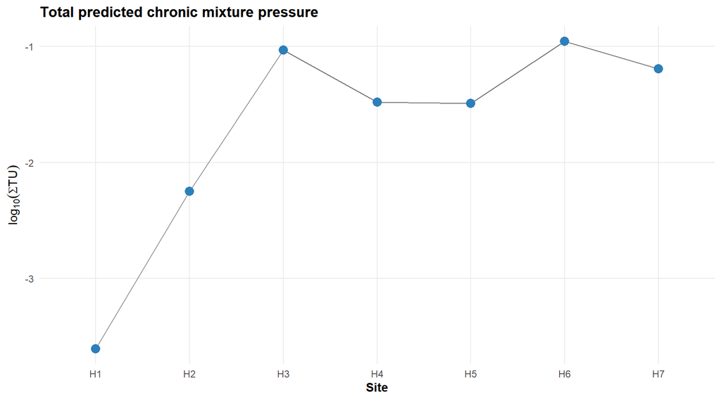

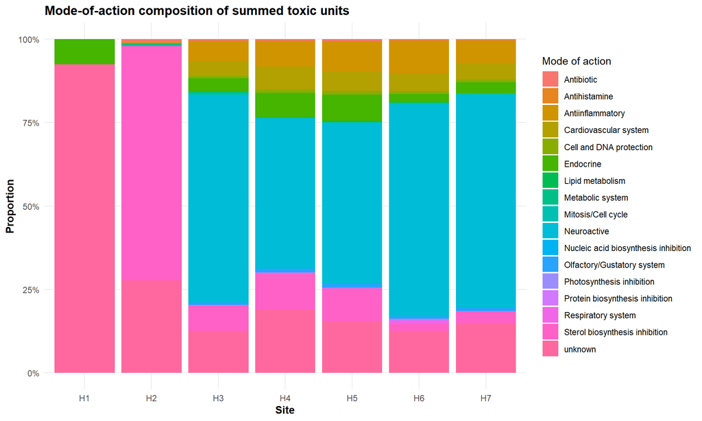

# 3 2. Complete-gene site-centroid response

Expression response retained for RDA.

| raw_vst_genes | nonzero_variance_genes | variable_site_centroid_genes | expression_libraries | transcriptomic_sites |
| --- | --- | --- | --- | --- |
| 151508 | 151508 | 151508 | 30 | 6 |

# 4 3. Exact six-site redundancy analysis

Exact RDA of the complete site-centroid transcriptome.

| model | predictor | response | response_type | constrained_r2 | adjusted_r2 | overall_F | overall_p | permutation_method | permutation_n | minimum_attainable_p | n_sites | n_response_features |
| --- | --- | --- | --- | --- | --- | --- | --- | --- | --- | --- | --- | --- |
| log10_STU_ToxC | log10_STU_ToxC | site_centroid_all_nonzero_variance_VST_genes_n151508 | complete_site_centroid_vst_expression | 0.214 | 0.0175 | 1.0892 | 0.2986 | exact enumeration of all predictor permutations | 720 | 0.0014 | 6 | 151508 |

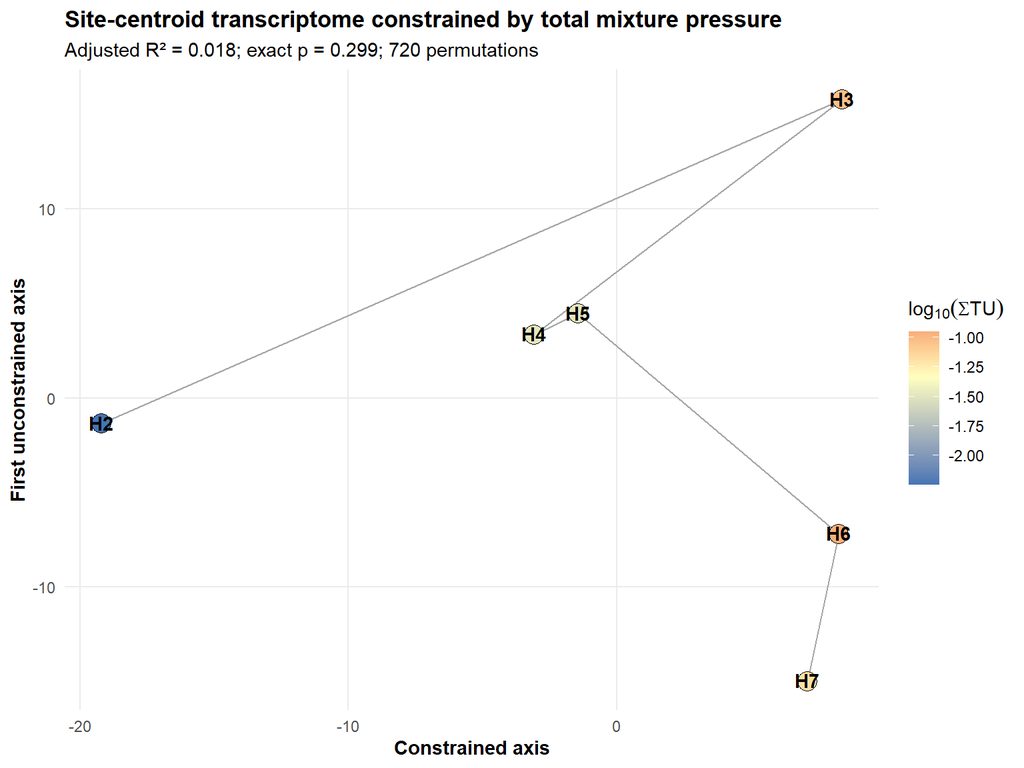

# 5 Interpretation

Step 02 quality-control gates.

| check_id | passed | status |
| --- | --- | --- |
| six_transcriptomic_sites | TRUE | PASS |
| five_libraries_per_site | TRUE | PASS |
| all_nonzero_variance_genes_used | TRUE | PASS |
| complete_pc_geometry | TRUE | PASS |
| all_720_permutations | TRUE | PASS |
| single_chemistry_predictor | TRUE | PASS |